# R Assignment 2

#### Problem 2

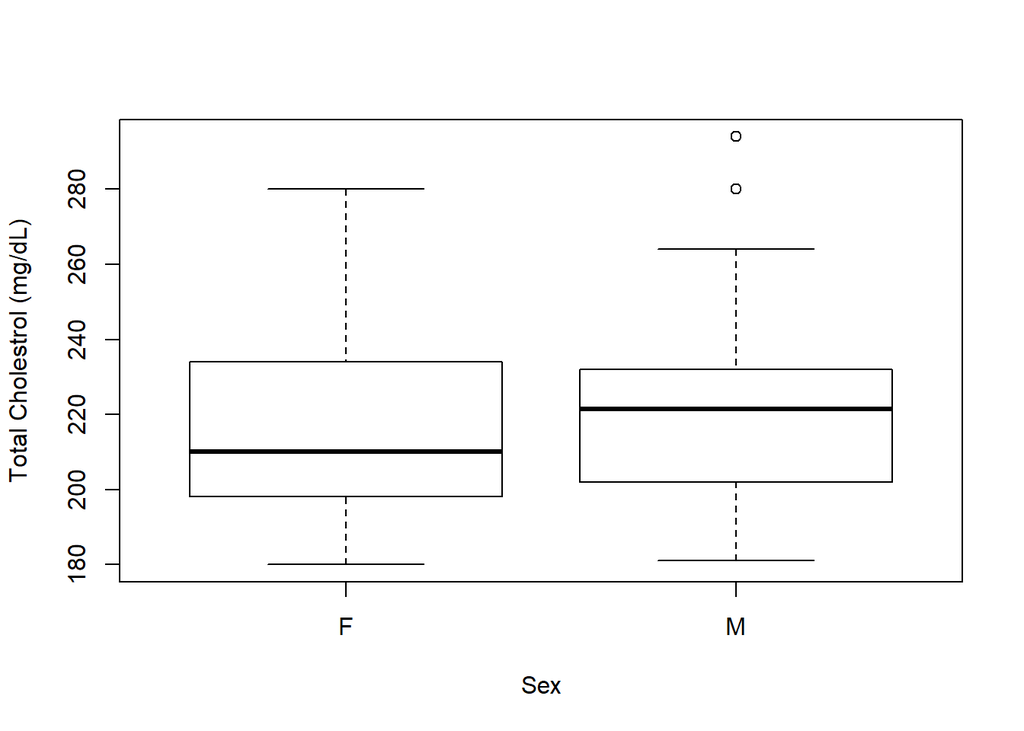

```r
boxplot(D.df$TotChol ~ D.df$Sex, ylab="Total Cholestrol (mg/dL)",
        xlab = "Sex")
```

##### Problem 3

```r
(tab1 <- table(D.df$Sex, D.df$MaritalStat))
```

```
##
##      D  M  S  W
##   F 11 20  9 10
##   M 13 14 17  6
```

```r
prop.table(tab1)*100
```

```
##
##      D  M  S  W
##   F 11 20  9 10
##   M 13 14 17  6
```

Table of counts and table of joint percentages have the same values. This is because the total number of datapoints is 100, so the percentages and counts are esentially the same.

##### Problem 4

```r
marginal_percentage_D <- ((11+13)/100)*100
marginal_percentage_M <- ((20+14)/100)*100
marginal_percentage_S <- ((9+17)/100)*100
marginal_percentage_W <- ((10+6)/100)*100

marginal_percentages <- c(marginal_percentage_D, marginal_percentage_M, marginal_percentage_S, marginal_percentage_W)

marginal_percentages
```

```
## [1] 24 34 26 16
```

##### Problem 5

```r
tab2 <- (Condrow.pct <- round(prop.table(tab1, margin=1) * 100, 1))
tab2[1,]
```

```
##  D  M  S  W
## 22 40 18 20
```

##### Problem 6

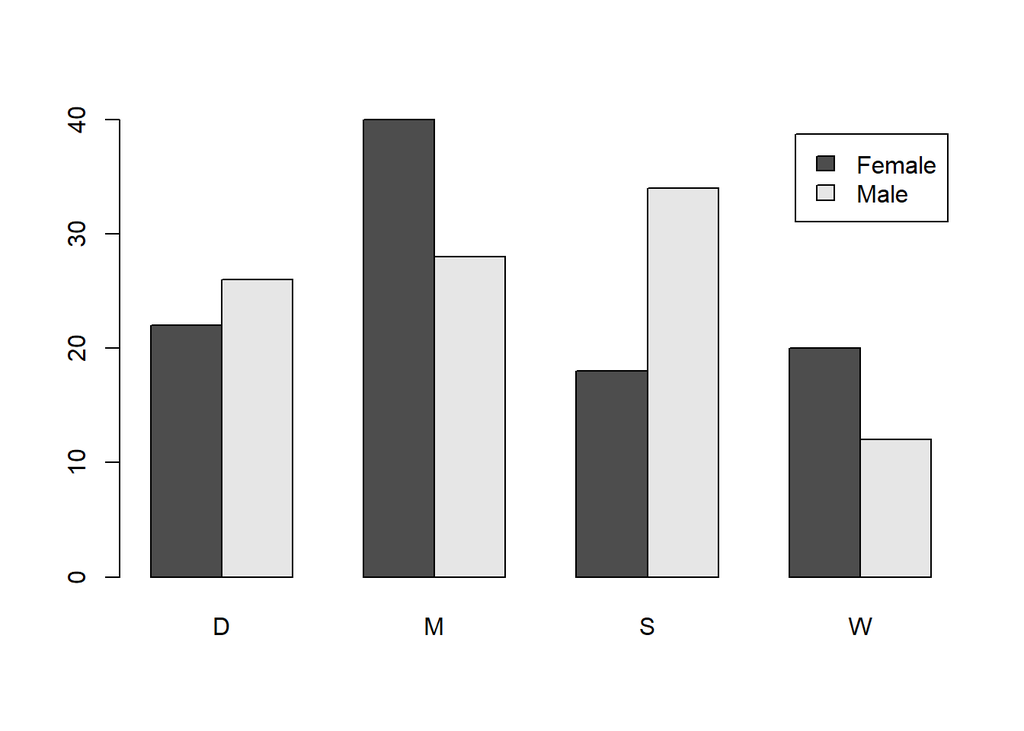

```r
barplot(tab2, legend.text=c("Female","Male"), beside=TRUE)
```

From the bar plot it is evident that male data and female data do not show the same patterns in all 4 marital statuses. For example, there are more males who are divorced compared to females, however there are more females who are married than male. There are also more single males than females, however more widowed females than males. This shows that the patterns in males and males is not consistent in all 4 marital status categories, So we can say that marital status and sex appear to be statistically dependent.